# DATA622 Assignment 1 (Large and Small Dataset Machine Learning methods and analysis)

### Logistic Regression (Test Data set)

After training on the test set, our metrics were similar to the train dataset. Accuracy : 0.6645 Sensitivity : 0.6576  
Specificity : 0.6891 AUC(0.7358227)

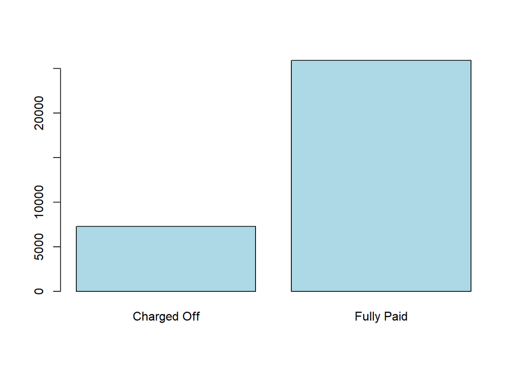

```r
library(ROCR)
set.seed(2024)

loans.test4 <- as.data.frame(loans.test)
barplot(table(loans.test4$loan_status) , col = 'lightblue')
```

```r
table(loans.test4$loan_status)
```

```
Charged Off  Fully Paid
       7263       25930
```

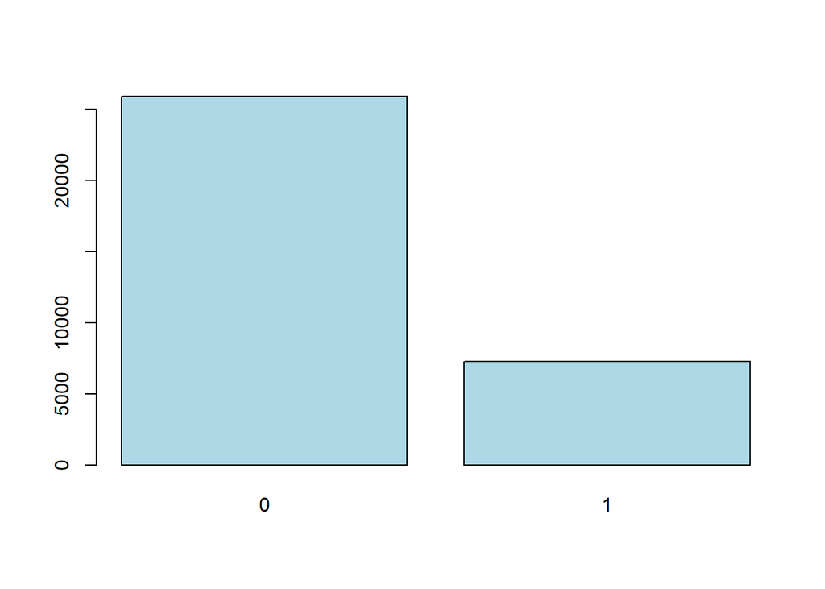

```r
#Use under and oversampling
# loans.oversample.test1 <- ovun.sample(loan_status ~ ., data = loans.test4, method = "both",N = 33193 , seed = 13)$data
# barplot(table(loans.oversample.test1 $loan_status) , col = 'lightblue')


loans.test1 <- loans.test4  %>% mutate(loan_outcome = ifelse(loan_status %in% c('Charged Off' ) , 1, ifelse(loan_status == 'Fully Paid' , 0,'none' )))

barplot(table(loans.test1$loan_outcome) , col = 'lightblue')
```

```r
table(loans.test1$loan_outcome)
```

```
    0     1
25930  7263
```

```r
loans.test1 <- loans.test1[, colnames(loans.test1)[colnames(loans.test1) != 'loan_status']]

loans.test1 <- loans.test1[, colnames(loans.test1)[colnames(loans.test1) != 'issue_d']]


loans.test1 <- loans.test1[, colnames(loans.test1)[colnames(loans.test1) != 'earliest_cr_line']]


# str(loan.test4)
# term
# grade
# sub_grade
# emp_length
# home_ownership
# verification_status
# purpose
# initial_list_status
# application_type
# loan_outcome
#
# class(loans.test1[1,"grade"])
#
# store.colnames1 = c("term",
#                     "grade",
#                     "sub_grade",
#                     "emp_length",
#                     "home_ownership",
#                     "verification_status",
#                     "purpose",
#                     "initial_list_status",
#                     "application_type",
#                     "loan_outcome")
#
store.colnames1=colnames(loans.test1)
loans.test3  = lapply(store.colnames1, function(column) factorize(column, loans.test1))
loans.test3 = as.data.frame(loans.test3 )
colnames(loans.test3)=store.colnames1


loans.over.2 <- train(loan_outcome ~ loan_amnt + term + int_rate + installment + sub_grade +
    emp_length + home_ownership + verification_status + purpose +
    dti + open_acc + pub_rec + revol_bal + revol_util + total_acc +
    initial_list_status + application_type + pub_rec_bankruptcies +
    time_since_fcline , data = loans.oversample3, method = "glm")

confusionMatrix(predict(loans.over.2, loans.test3), as.factor(loans.test3$loan_outcome))
```

```
Confusion Matrix and Statistics

          Reference
Prediction     0     1
         0 17051  2258
         1  8879  5005

               Accuracy : 0.6645
                 95% CI : (0.6594, 0.6696)
    No Information Rate : 0.7812
    P-Value [Acc > NIR] : 1

                  Kappa : 0.261

 Mcnemar's Test P-Value : <2e-16

            Sensitivity : 0.6576
            Specificity : 0.6891
         Pos Pred Value : 0.8831
         Neg Pred Value : 0.3605
             Prevalence : 0.7812
         Detection Rate : 0.5137
   Detection Prevalence : 0.5817
      Balanced Accuracy : 0.6733

       'Positive' Class : 0
```

```r
loans.2.prediction <- prediction(predict(loans.over.2, newdata = loans.test3, type = "prob")[,"1"], loans.test3$loan_outcome)
performance(loans.2.prediction , measure = "auc")@y.values
```

```
[[1]]
[1] 0.7358227
```

```r
# Make predictions and pre accuracy for full model
probabilities <- predict(full.reg, loans.test3, type = "response")
predicted.classes <- ifelse(probabilities > 0.5, 1, 0)
# Prediction accuracy
observed.classes <- loans.test3$loan_outcome
mean(predicted.classes == observed.classes)
```

```
[1] 0.6645678
```

```r
# Make predictions and pre accuracy for stepwise model
probabilities <- predict(loans.reg, loans.test3, type = "response")
predicted.classes <- ifelse(probabilities > 0.5, 1, 0)
# Prediction accuracy
observed.classes <- loans.test3$loan_outcome
mean(predicted.classes == observed.classes)
```

```
[1] 0.6644775
```

```r
get_logistic_error(full.reg, data = loans.test3,
                   res = "loan_outcome", pos = 1, neg = 0, cut = 0.5)
```

```
[1] 0.3354322
```

```r
get_logistic_error(loans.reg, data = loans.test3,
                   res = "loan_outcome", pos = 1, neg = 0, cut = 0.5)
```

```
[1] 0.3355225
```

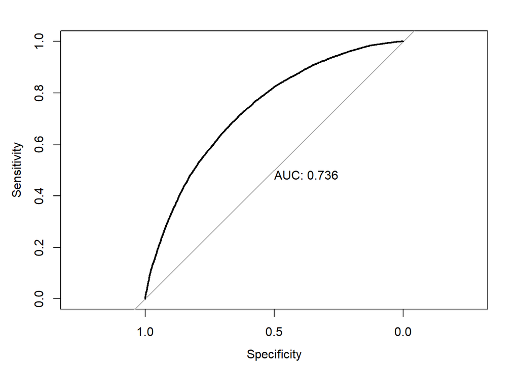

```r
#A good model will have a high AUC, that is as often as possible a high sensitivity and specificity.
test_prob = predict(loans.reg, newdata = loans.test3, type = "response")
test_roc = roc( loans.test3$loan_outcome ~ test_prob, plot = TRUE, print.auc = TRUE)
```

```r
as.numeric(test_roc$auc)
```

```
[1] 0.7358227
```

### Random Forest Model

We implemented the random forest model, however, we were not able to use some of the functionality of the randomForestExplainer model. Therefore we were able to display some importance measures.

The first measure is computed from permuting OOB data: For each tree, the prediction error on the out-of-bag portion of the data is recorded (error rate for classification, MSE for regression). Then the same is done after permuting each predictor variable. The difference between the two are then averaged over all trees, and normalized by the standard deviation of the differences. If the standard deviation of the differences is equal to 0 for a variable, the division is not done (but the average is almost always equal to 0 in that case). The second measure is the total decrease in node impurities from splitting on the variable, averaged over all trees. For classification, the node impurity is measured by the Gini index. For regression, it is measured by residual sum of squares.

```r
#install.packages("randomForestExplainer")
library(randomForest)
library(ipred)
library(randomForestExplainer)

set.seed(2024)

seat_forest = randomForest(loan_outcome ~ ., data = loans.oversample3, mtry = 3, importance = TRUE, ntrees = 500)
seat_forest
```

```
Call:
 randomForest(formula = loan_outcome ~ ., data = loans.oversample3,      mtry = 3, importance = TRUE, ntrees = 500)
               Type of random forest: classification
                     Number of trees: 500
No. of variables tried at each split: 3

        OOB estimate of  error rate: 8.36%
Confusion matrix:
      0     1 class.error
0 33982  4611  0.11947763
1  1866 36995  0.04801729
```

```r
print(seat_forest)
```

```
Call:
 randomForest(formula = loan_outcome ~ ., data = loans.oversample3,      mtry = 3, importance = TRUE, ntrees = 500)
               Type of random forest: classification
                     Number of trees: 500
No. of variables tried at each split: 3

        OOB estimate of  error rate: 8.36%
Confusion matrix:
      0     1 class.error
0 33982  4611  0.11947763
1  1866 36995  0.04801729
```

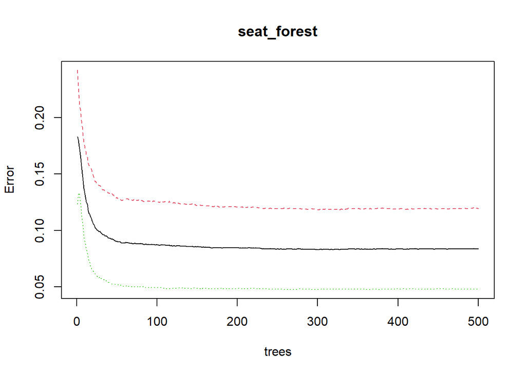

```r
plot(seat_forest)
```

```r
# colnames(loans.oversample3)
# str(loans.oversample3)
# colnames(loans.test3)
# str(loans.test3)

levels( loans.oversample3$home_ownership)
```

```
[1] "ANY"      "MORTGAGE" "OWN"      "RENT"
```

```r
allvalues <- unique(levels( loans.oversample3$home_ownership))
loans.test3$home_ownership <- x <- factor(loans.test3$home_ownership, levels = allvalues)
levels( loans.test3$home_ownership)
```

```
[1] "ANY"      "MORTGAGE" "OWN"      "RENT"
```

```r
common <- intersect(names(loans.oversample3), names(loans.test3))
for (p in common) {
  if (class(loans.oversample3[[p]]) == "factor") {
    levels(loans.test3[[p]]) <- levels(loans.oversample3[[p]])
  }
}

seat_forest_tst_perd = predict(seat_forest, loans.test3)
table(predicted = seat_forest_tst_perd, actual = loans.test3$loan_outcome)
```

```
         actual
predicted     0     1
        0 20156  3341
        1  5774  3922
```

```r
rf_cm <- confusionMatrix(seat_forest_tst_perd, loans.test3$loan_outcome)


randomForest::importance(seat_forest, type=1)
```

```
                     MeanDecreaseAccuracy
loan_amnt                        97.71957
term                             34.36486
int_rate                         70.05303
installment                     114.92811
grade                            43.68179
sub_grade                        75.03905
emp_length                      169.14120
home_ownership                  102.98117
annual_inc                       94.32410
verification_status              52.81359
purpose                          89.98132
dti                             115.42503
open_acc                        126.29566
pub_rec                          85.39829
revol_bal                       156.45117
revol_util                       96.26056
total_acc                       117.82003
initial_list_status              31.85327
application_type                 34.42225
pub_rec_bankruptcies             83.40827
time_since_fcline               108.80780
```

```r
randomForest::importance(seat_forest, type=2)
```

```
                     MeanDecreaseGini
loan_amnt                  2156.30125
term                        419.29550
int_rate                   2898.03363
installment                2557.74510
grade                      1305.78409
sub_grade                  3283.18077
emp_length                 2893.53889
home_ownership              823.51926
annual_inc                 2611.73969
verification_status         774.22029
purpose                    1339.35019
dti                        3294.59734
open_acc                   1971.88136
pub_rec                     450.61513
revol_bal                  2741.31150
revol_util                 2905.64451
total_acc                  2291.79049
initial_list_status         380.49145
application_type             37.99733
pub_rec_bankruptcies        304.65887
time_since_fcline          2716.11220
```

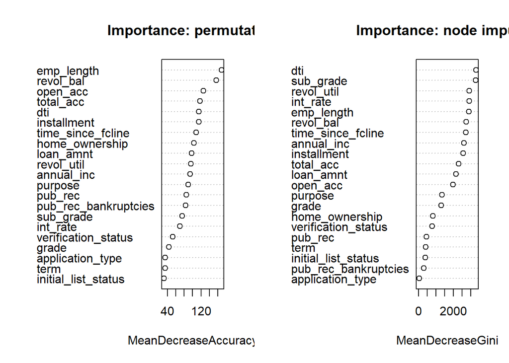

```r
par(mfrow = c(1, 2))
varImpPlot(seat_forest, type=1, main = "Importance: permutation")
varImpPlot(seat_forest, type=2, main = "Importance: node impurity")
```

```r
#var_imp <- measure_importance(seat_forest)

perf_dt4 <- data.frame(Model = "Random forest", Accuracy = rf_cm$overall[1], Sensitivity = rf_cm$byClass[1], Specificity = rf_cm$byClass[2])
performance_df <- rbind(performance_df, perf_dt4)

performance_df
```

```
                                    Model  Accuracy Sensitivity Specificity
Accuracy  loans.reg Logistic with stepAIC 0.6731350   0.6847482   0.6614412
Accuracy1          Decision Tree Baseline 0.7834784   0.1097343   0.9721944
Accuracy2                   Random forest 0.7253939   0.7773236   0.5399972
```

## Medium Data Set (End to End ML Analysis)

### Data set Introduction

The large data set consists of about 284,000 card transactions that are labelled as non-fraud and fraud. It is a real data set from a European financial institution, which is why the features are masked. They are the result of extensive PCA. Additionally, it is a highly imbalanced data set, as there are several orders of magnitude more non-fraud than fraud transactions.

### Data Exploration & Plots

```r
set.seed(2024)
path = "https://github.com/BanuB/Card_Transaction_Fraud/raw/refs/heads/master/creditcard.parquet"

tx_raw = read_parquet(path)
```

```r
summary(tx_raw)
```

```
      Time              V1                  V2                  V3
 Min.   :     0   Min.   :-56.40751   Min.   :-72.71573   Min.   :-48.3256
 1st Qu.: 54202   1st Qu.: -0.92037   1st Qu.: -0.59855   1st Qu.: -0.8904
 Median : 84692   Median :  0.01811   Median :  0.06549   Median :  0.1799
 Mean   : 94814   Mean   :  0.00000   Mean   :  0.00000   Mean   :  0.0000
 3rd Qu.:139321   3rd Qu.:  1.31564   3rd Qu.:  0.80372   3rd Qu.:  1.0272
 Max.   :172792   Max.   :  2.45493   Max.   : 22.05773   Max.   :  9.3826
       V4                 V5                   V6                 V7
 Min.   :-5.68317   Min.   :-113.74331   Min.   :-26.1605   Min.   :-43.5572
 1st Qu.:-0.84864   1st Qu.:  -0.69160   1st Qu.: -0.7683   1st Qu.: -0.5541
 Median :-0.01985   Median :  -0.05434   Median : -0.2742   Median :  0.0401
 Mean   : 0.00000   Mean   :   0.00000   Mean   :  0.0000   Mean   :  0.0000
 3rd Qu.: 0.74334   3rd Qu.:   0.61193   3rd Qu.:  0.3986   3rd Qu.:  0.5704
 Max.   :16.87534   Max.   :  34.80167   Max.   : 73.3016   Max.   :120.5895
       V8                  V9                 V10                 V11
 Min.   :-73.21672   Min.   :-13.43407   Min.   :-24.58826   Min.   :-4.79747
 1st Qu.: -0.20863   1st Qu.: -0.64310   1st Qu.: -0.53543   1st Qu.:-0.76249
 Median :  0.02236   Median : -0.05143   Median : -0.09292   Median :-0.03276
 Mean   :  0.00000   Mean   :  0.00000   Mean   :  0.00000   Mean   : 0.00000
 3rd Qu.:  0.32735   3rd Qu.:  0.59714   3rd Qu.:  0.45392   3rd Qu.: 0.73959
 Max.   : 20.00721   Max.   : 15.59500   Max.   : 23.74514   Max.   :12.01891
      V12                V13                V14                V15
 Min.   :-18.6837   Min.   :-5.79188   Min.   :-19.2143   Min.   :-4.49894
 1st Qu.: -0.4056   1st Qu.:-0.64854   1st Qu.: -0.4256   1st Qu.:-0.58288
 Median :  0.1400   Median :-0.01357   Median :  0.0506   Median : 0.04807
 Mean   :  0.0000   Mean   : 0.00000   Mean   :  0.0000   Mean   : 0.00000
 3rd Qu.:  0.6182   3rd Qu.: 0.66251   3rd Qu.:  0.4931   3rd Qu.: 0.64882
 Max.   :  7.8484   Max.   : 7.12688   Max.   : 10.5268   Max.   : 8.87774
      V16                 V17                 V18
 Min.   :-14.12985   Min.   :-25.16280   Min.   :-9.498746
 1st Qu.: -0.46804   1st Qu.: -0.48375   1st Qu.:-0.498850
 Median :  0.06641   Median : -0.06568   Median :-0.003636
 Mean   :  0.00000   Mean   :  0.00000   Mean   : 0.000000
 3rd Qu.:  0.52330   3rd Qu.:  0.39968   3rd Qu.: 0.500807
 Max.   : 17.31511   Max.   :  9.25353   Max.   : 5.041069
      V19                 V20                 V21
 Min.   :-7.213527   Min.   :-54.49772   Min.   :-34.83038
 1st Qu.:-0.456299   1st Qu.: -0.21172   1st Qu.: -0.22839
 Median : 0.003735   Median : -0.06248   Median : -0.02945
 Mean   : 0.000000   Mean   :  0.00000   Mean   :  0.00000
```

[output cut: 8 more lines]

```
 Max.   : 10.503090   Max.   : 22.52841   Max.   : 4.58455
      V25                 V26                V27
 Min.   :-10.29540   Min.   :-2.60455   Min.   :-22.565679
 1st Qu.: -0.31715   1st Qu.:-0.32698   1st Qu.: -0.070840
 Median :  0.01659   Median :-0.05214   Median :  0.001342
 Mean   :  0.00000   Mean   : 0.00000   Mean   :  0.000000
 3rd Qu.:  0.35072   3rd Qu.: 0.24095   3rd Qu.:  0.091045
 Max.   :  7.51959   Max.   : 3.51735   Max.   : 31.612198
      V28                Amount             Class
 Min.   :-15.43008   Min.   :    0.00   Min.   :0.000000
 1st Qu.: -0.05296   1st Qu.:    5.60   1st Qu.:0.000000
 Median :  0.01124   Median :   22.00   Median :0.000000
 Mean   :  0.00000   Mean   :   88.35   Mean   :0.001728
 3rd Qu.:  0.07828   3rd Qu.:   77.17   3rd Qu.:0.000000
 Max.   : 33.84781   Max.   :25691.16   Max.   :1.000000
```

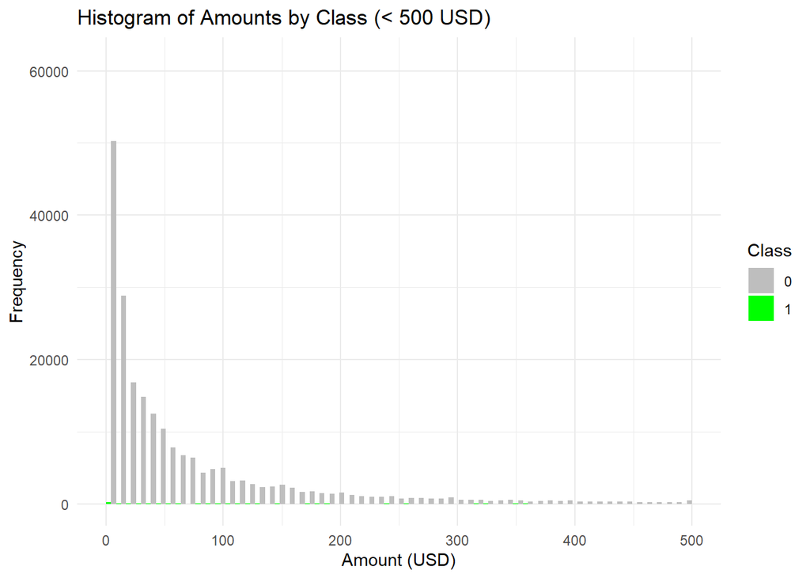

```r
tx_raw$Class = as.factor(tx_raw$Class) #Convert Class column to factor

tx_raw = tx_raw %>%
  mutate(datetime = as.POSIXct("2024-01-01 00:00:00", tz = "UTC") + seconds(Time)) #Make new column that shows datetime

ggplot(tx_raw, aes(x = Amount, fill = Class)) +
  geom_histogram(position = "dodge", bins = 60) +
  labs(title = "Histogram of Amounts by Class (< 500 USD)", x = "Amount (USD)", y = "Frequency") +
  theme_minimal() +
  scale_fill_manual(values = c('grey', 'green')) +
  xlim(0, 500)
```

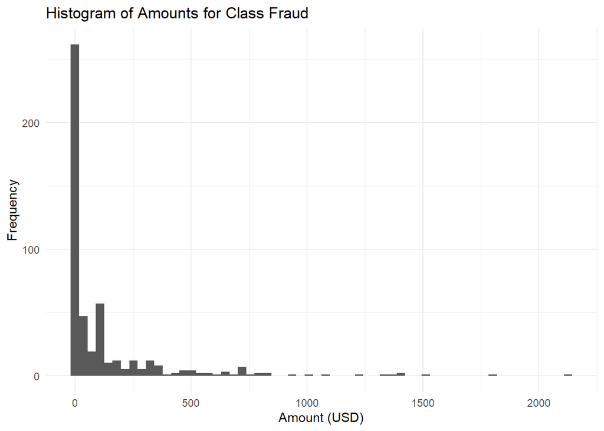

```r
tx_1 = tx_raw %>%
  filter(Class == 1)

ggplot(tx_1, aes(x = Amount)) +
  geom_histogram(position = "dodge", bins = 60) +
  labs(title = "Histogram of Amounts for Class Fraud", x = "Amount (USD)", y = "Frequency") +
  theme_minimal()
```

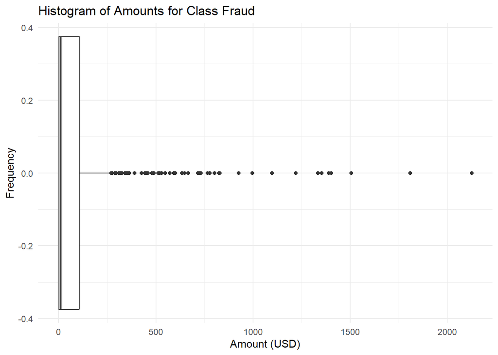

```r
#Outlier plot
ggplot(tx_1, aes(x = Amount)) +
  geom_boxplot(position = "dodge", bins = 60) +
  labs(title = "Histogram of Amounts for Class Fraud", x = "Amount (USD)", y = "Frequency") +
  theme_minimal()
```

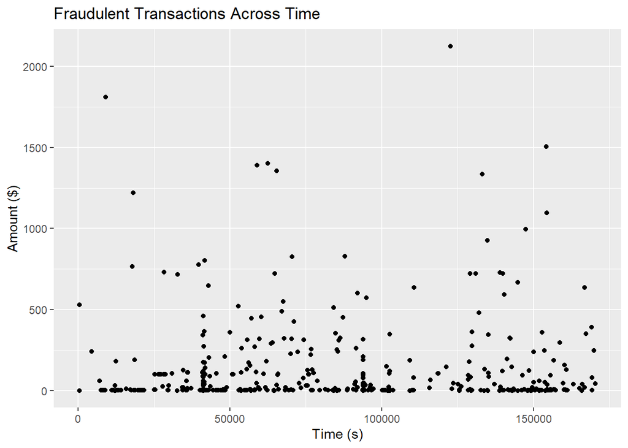

```r
# Scatterplot

tx_1 %>% ggplot(aes(x=Time, y=Amount)) +
  geom_point() +
  labs(
  y = "Amount ($)",
  x = "Time (s)",
  title= "Fraudulent Transactions Across Time"
 )
```

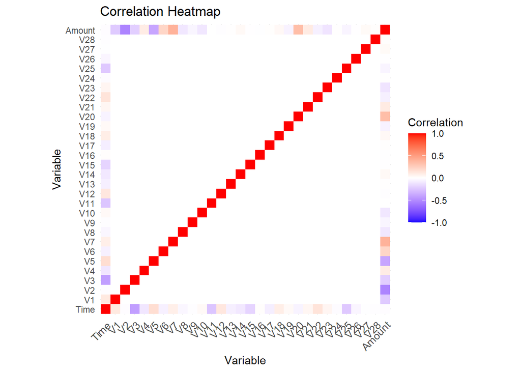

```r
#Correlation Heatmap
tx_raw_numeric = tx_raw %>%
  dplyr::select(!c(Class, datetime))
cor_matrix = cor(tx_raw_numeric)
cor_matrix = melt(cor_matrix)

ggplot(data = cor_matrix, aes(x = Var1, y = Var2, fill = value)) +
  geom_tile() +
  scale_fill_gradient2(low = "blue", high = "red", mid = "white",
                       midpoint = 0, limit = c(-1, 1), space = "Lab",
                       name = "Correlation") +
  theme_minimal() +
  theme(axis.text.x = element_text(angle = 45, vjust = 1,
                                   size = 10, hjust = 1)) +
  coord_fixed() +
  labs(title = "Correlation Heatmap", x = "Variable", y = "Variable")
```

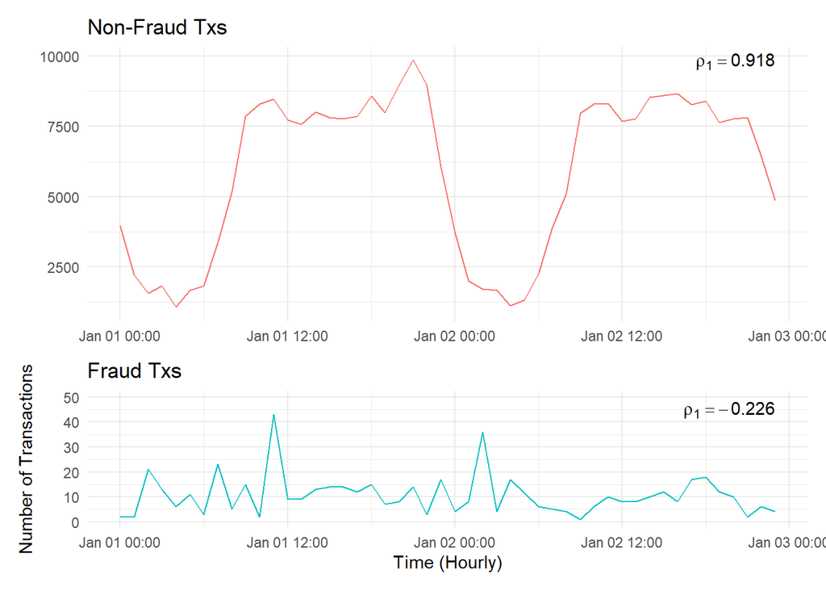

```r
#----Time-Series for Transactions----
tx_transactions <- tx_raw %>%
  mutate(datetime_hour = floor_date(datetime, "hour")) %>%
  group_by(datetime_hour, Class) %>%
  summarise(transaction_count = n())

tx_trans_1 <- ggplot(tx_transactions, aes(x = datetime_hour, y = transaction_count, color = as.factor(Class))) +
  geom_line() +
  theme_minimal() +
  labs(title = 'Fraud Txs', y = "Number of Transactions", x = "Time (Hourly)") +
  scale_y_continuous(limits = c(0, 50)) +
  theme(legend.position = "none") +
  annotate("text", x = max(tx_transactions$datetime_hour), y = 45, label = expression(rho[1] == -0.226), hjust = 1)

tx_trans_0 <- ggplot(tx_transactions, aes(x = datetime_hour, y = transaction_count, color = as.factor(Class))) +
  geom_line() +
  theme_minimal() +
  labs(title = 'Non-Fraud Txs', x = NULL, y = NULL, color = "Class") +
  scale_y_continuous(limits = c(1000, max(tx_transactions$transaction_count))) +
  theme(legend.position = "none") +
  annotate("text", x = max(tx_transactions$datetime_hour), y = max(tx_transactions$transaction_count) - 50, label = expression(rho[1] == 0.918), hjust = 1)

# Combine the two plots
tx_transactions_plot <- (tx_trans_0 / tx_trans_1) + plot_layout(heights = c(2, 1))
print(tx_transactions_plot)
```

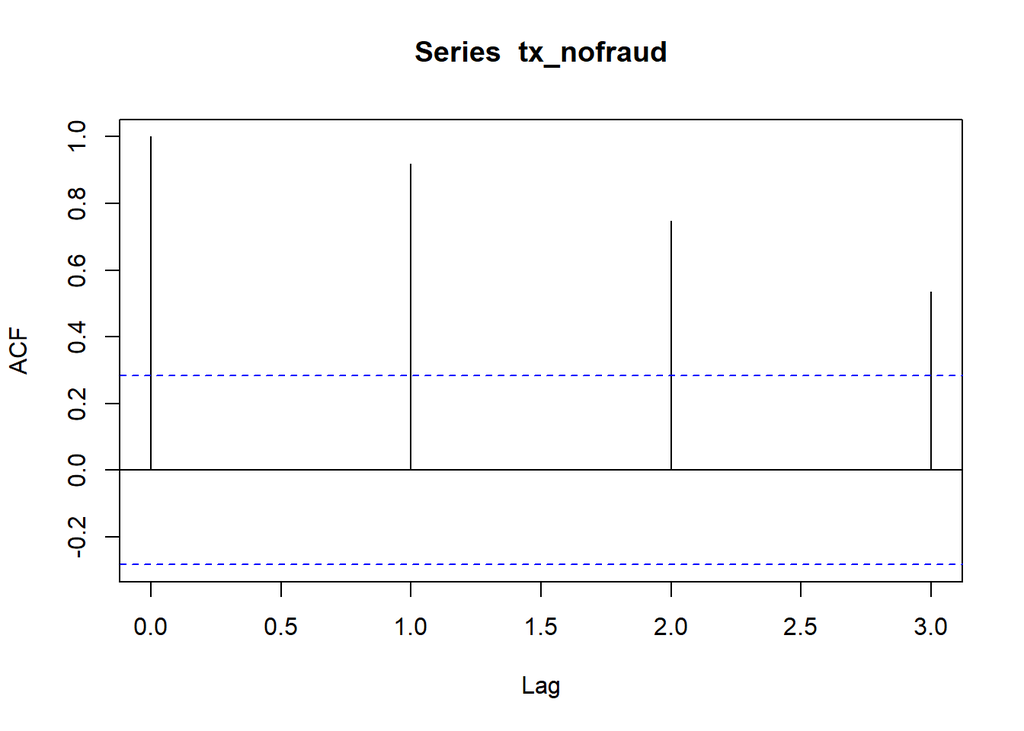

```r
#----Auto- and Cross-correlations----
tx_nofraud = tx_transactions %>%
  filter(Class == 0) %>%
  dplyr::select(transaction_count)
tx_nofraud = tx_nofraud$transaction_count

tx_nofraud_autocor = acf(tx_nofraud, lag.max = 3, plot = T)
```

```r
tx_nofraud_autocor
```

```
Autocorrelations of series 'tx_nofraud', by lag

    0     1     2     3
1.000 0.918 0.747 0.536
```

When investigating the plots from the EDA above one thing becomes clear: the data set is HEAVILY imbalanced. As discussed in the introduction above, this is unsurprising given the nature of non-fraud versus fraud transactions; however, this is an important consideration when selecting the models to run. Weak learners will likely not be as strong in performance as ensemble methods would be.

Additionally, there are a few more interesting observations. For example, the correlation matrix between all features show no strong correlation between each other. This is important for several machine learning algorithms, and considering that this data set has undergone feature engineering and PCA, it is unsurprising that this is case. Nevertheless, this plot should be part of any machine learning implementation.

Lastly, these auto-correlations can be seen in the ACF plot, that shows different lags. It can be seen that the strongest lag is 1, with decreasing auto-correlations with larger lags.

Next, we split the data to prepare for the machine learning implementation. We chose to split the data 80/20 for training and test set. We deferred from a validation set as we are not going to engage in hyper parameter tuning in this exercise.

### Data Preparation

```r
set.seed(2024)
library(caret)
library(e1071)
library(randomForest)
library(rpart)
library(pROC)
library(ranger)
library(ranger)

tx_raw$Class = as.factor(tx_raw$Class)

# Ensure datetime is of the correct type
tx_raw$datetime = as.POSIXct(tx_raw$datetime)

# Split the data into training and testing sets
trainIndex = createDataPartition(tx_raw$Class, p = 0.8, list = FALSE)
dataTrain = tx_raw[trainIndex, ]
dataTest = tx_raw[-trainIndex, ]

#Define CV
train_control = trainControl(method = "cv", number = 10)
```

### Algorithm Selection

Given the fact the this is a highly imbalanced data set, a weak learner, such as a decision tree or logistic regression will likely not be very successful. Therefore, the better choice will likely be an ensemble. In order to test this, we will run a logistic regression, and a single decision tree. We wanted to also include a random forest, however, the large data set was computationally too expensive. In the real world, we would certainly use some type of ensemble method, like random forest and XGBoost.

#### Train Models

```r
set.seed(2024)
#Logistic Regression
time_logistic_train = system.time({
  logistic_model = train(Class ~ ., data = dataTrain, method = "glm", family = "binomial", trControl = train_control)})

#Decision Tree
time_tree_train = system.time({
  tree_model = train(Class ~ ., data = dataTrain, method = "rpart", trControl = train_control)})
```

#### Predictions and Evaluation

```r
#Logistic Regression Prediction
time_logistic_pred = system.time({
  logistic_pred = predict(logistic_model, dataTest)
  logistic_probs = predict(logistic_model, dataTest, type = "prob")[, 2]
})

#Decision Tree Prediction
time_tree_pred = system.time({
  tree_pred = predict(tree_model, dataTest)
  tree_probs = predict(tree_model, dataTest, type = "prob")[, 2]
})

# Logistic Regression Confusion Matrix
confusionMatrix(logistic_pred, dataTest$Class)
```

```
Confusion Matrix and Statistics

          Reference
Prediction     0     1
         0 56852    39
         1    11    59

               Accuracy : 0.9991
                 95% CI : (0.9988, 0.9993)
    No Information Rate : 0.9983
    P-Value [Acc > NIR] : 6.453e-08

                  Kappa : 0.702

 Mcnemar's Test P-Value : 0.0001343

            Sensitivity : 0.9998
            Specificity : 0.6020
         Pos Pred Value : 0.9993
         Neg Pred Value : 0.8429
             Prevalence : 0.9983
         Detection Rate : 0.9981
   Detection Prevalence : 0.9988
      Balanced Accuracy : 0.8009

       'Positive' Class : 0
```

```r
# Decision Tree Confusion Matrix
confusionMatrix(tree_pred, dataTest$Class)
```

```
Confusion Matrix and Statistics

          Reference
Prediction     0     1
         0 56847    32
         1    16    66

               Accuracy : 0.9992
                 95% CI : (0.9989, 0.9994)
    No Information Rate : 0.9983
    P-Value [Acc > NIR] : 1.581e-08

                  Kappa : 0.7329

 Mcnemar's Test P-Value : 0.03038

            Sensitivity : 0.9997
            Specificity : 0.6735
         Pos Pred Value : 0.9994
         Neg Pred Value : 0.8049
             Prevalence : 0.9983
         Detection Rate : 0.9980
   Detection Prevalence : 0.9986
      Balanced Accuracy : 0.8366

       'Positive' Class : 0
```

```r
#Benchmarking Training and Prediction Time
benchmark_results = data.frame(
  Model = c("Logistic Regression", "Decision Tree"),
  Training_Time = c(time_logistic_train[3], time_tree_train[3]),
  Prediction_Time = c(time_logistic_pred[3], time_tree_pred[3])
)

print(benchmark_results)
```

```
                Model Training_Time Prediction_Time
1 Logistic Regression        106.75            4.07
2       Decision Tree        154.81            2.34
```

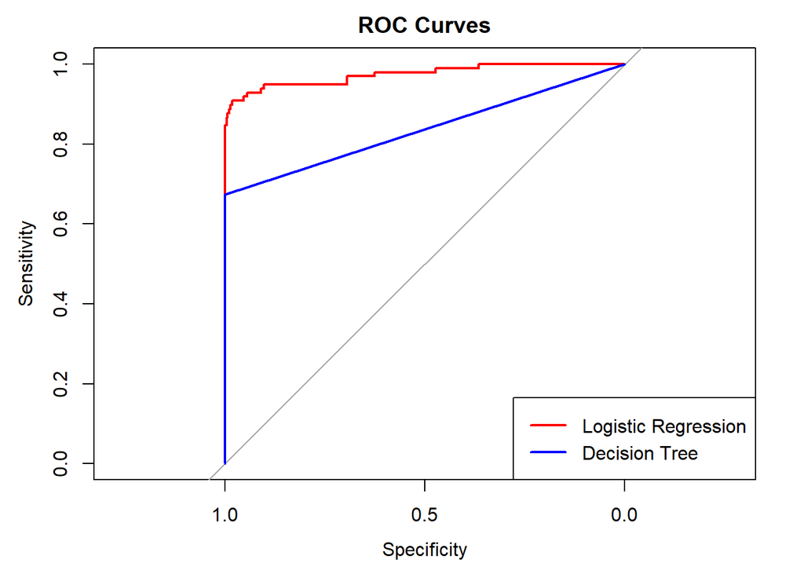

```r
#ROC and AUC Curves
#ROC

roc_logistic = roc(dataTest$Class, logistic_probs)
roc_tree = roc(dataTest$Class, tree_probs)

plot(roc_logistic, col = "red", main = "ROC Curves", lwd = 2)
lines(roc_tree, col = "blue", lwd = 2)
legend("bottomright", legend = c("Logistic Regression", "Decision Tree"),
       col = c("red", "blue"), lwd = 2)
```

```r
#AUC
auc_logistic = auc(roc_logistic)
auc_tree = auc(roc_tree)

print(paste("AUC for Logistic Regression:", auc_logistic))
```

```
[1] "AUC for Logistic Regression: 0.974355477379035"
```

```r
print(paste("AUC for Decision Tree:", auc_tree))
```

```
[1] "AUC for Decision Tree: 0.836573906420983"
```

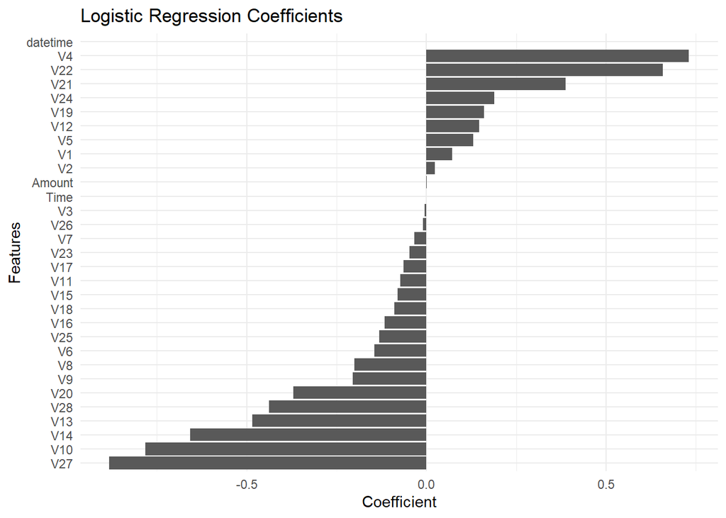

```r
coefficients <- tidy(logistic_model$finalModel)
coefficients <- coefficients[coefficients$term != "(Intercept)", ]  # Remove intercept for better visualization
ggplot(coefficients, aes(x = reorder(term, estimate), y = estimate)) +
  geom_bar(stat = "identity") +
  coord_flip() +
  labs(title = "Logistic Regression Coefficients", x = "Features", y = "Coefficient") +
  theme_minimal()
```

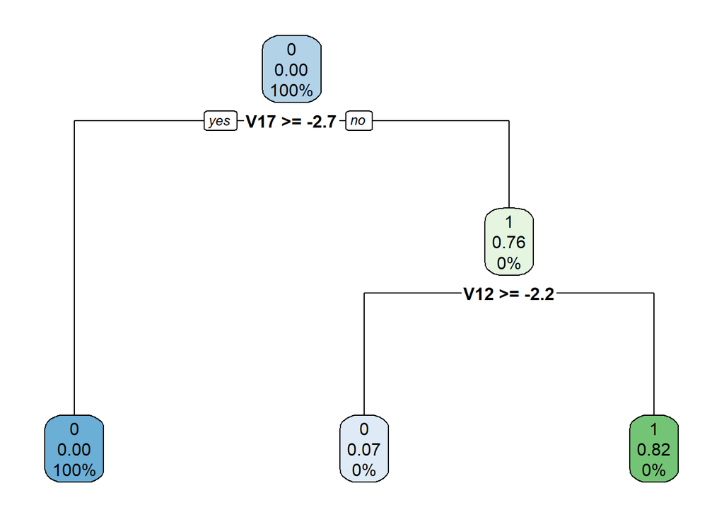

```r
rpart.plot(tree_model$finalModel)
```

```r
rules1<- rpart.rules(tree_model$finalModel)
rules1 %>% kable()
```

|  | .outcome |  |  |  |  |  |  |  |  |
| --- | --- | --- | --- | --- | --- | --- | --- | --- | --- |
| 2 | 0.00 | when | V17 | >= | -2.7 |  |  |  |  |
| 6 | 0.07 | when | V17 | < | -2.7 | & | V12 | >= | -2.2 |
| 7 | 0.82 | when | V17 | < | -2.7 | & | V12 | < | -2.2 |

In order to further understand the predictive quality of both models, we decided to compute ROC curves that plot specificity against sensitivity, and here found, interestingly, that the logistic regression was much better across the board than the decision tree. It is likely that the tree over fit, which leads to diminished predictive quality. While the accuracy is still high, this does not mean that it stays high with other unseen data.

Therefore, in the current case, we’d be deciding to utilize logistic regression over the decision tree. While again, an ensemble of trees would likely outperform the logistic regression, even with a smaller data set.

## Conclusion and Summary Essay

**Note:** Both dataset had responded well to Decision Tree and Logistic Regression modeling as expected.

On the lending loan dataset, we have updated results on 3 models and their performance metrics such as accuracy, sensitivity and specificity.

On the fraud dataset, we decided to utilize the logistic regression over the decision tree. While we did not run the ensemble methods here which may yield a better result in the future.

**Takeaways:** Additionally the RandomForest took significant amount of time to run and we were unable to load the importance measures through the randomForestExplainer package. We were unable to save the .RDA file with the importance measures on the test model output. We would like to further review this in the future. We would like to further expand on time series with “fpp3” package in the future on the credit dataset to look at further extrapolations of the time series data and forecasting methods to answer questions such as can we forecast credit card fraud given the dataset, are there any seasonal patterns when frauds occur?

## References

https://www.kaggle.com/code/krishnaraj30/xgboost-loan-defaulters-prediction https://www.kaggle.com/code/heidarmirhajisadati/advancedtechniques-for-detecting-credit-card-fraud/notebook https://rpubs.com/DeclanStockdale/799284 https://htmlpreview.github.io/?https://github.com/geneticsMiNIng/BlackBoxOpener/blob/master/randomForestExplainer/inst/doc/randomForestExplainer.html